# Telecom Pandas Practical Case: Understanding fixed penetration trends in Colombia

- Version: v1.0
- Author: Juan David Rodriguez

# Case Instructions

This case intends to evaluate and develop your capacity to use data and machine learning models in python to answer practical questions and assess business implications. Please read instructions carefully, each code block has a validation code, run each item sequentially to make sure that the validation code is valid in each step of the process. This case will allow you to:

- Read and store in a DataFrame a compressed dataset
- Clear and fix isues with outliers
- Filter and aggregate data
- Use basic python modules to visualize data
- Prepare data to enter a machine learning model
- Run a machine learning model (k-means clustering) using real data

# Context and Background

This case uses real data from Colombia’s Telecom Industry, the objective is to understand the evolution of the fixed internet access in Colombia: As a developing country, Colombia has been trying to massify and improve penetration of the internet service. Most of the big cities have advanced telecommunications' offers, while small cities in rural areas have had limited internet access based on legacy technologies. Colombian government have developed a series of initiatives to improve fixed internet services in rural areas, aiming to improve digitalization.

# Questions to answer:

1. How is the evolution of the general penetration of fixed internet in Colombia? Are there specific trends that can be identified from the graph? Is the current penetration high or low? What is the maximum penetration that can be reached if it is measured as instructed in this question?
2. Does the evolution of the penetration differ for big and small cities? Is the gap increasing or decreasing (take a clear position and support it with numbers resulting from your analysis)
3. How does average internet offered speeds vary between big cities and small cities? Is the gap increasing or decreasing (take a clear position and support it with numbers resulting from your analysis)
4. Is the distribution between internet service providers different in big cities and small cities? What are the pros and cons of using a pie chart to present this information?
5. Previous questions have shown that two very different groups of cities can be separated by population (size of the city), Can cities be grouped or clustered based on other indicators in the dataset? What are the characteristics from each cluster?
6. Liberty Latin America currently does not have a B2C (Business-to-Consumer) operation in Colombia. Based on the data provided in the case study, please provide a recommendation for the most effective entry strategy and identify specific groups of cities for its implementation.

# Sources of data:

The Colombian government has enabled the website https://www.datos.gov.co/, where public data has been downloaded for internet access penetration, providers, type of technology and population for each city. A simple preparation was performed to reduce the size of the file and merge the different sources into one. The base resulting file is called 'Fix_Internet_Tech_City_Period.csv.gz'

### Import Libraries

Import Pandas, Numpy, Scipy vq, Seaborn and Matplotlib

```python
!pip install pandas
!pip install numpy
!pip install matplotlib
!pip install seaborn
!pip install sklearn
!pip install scipy
!pip install scikit-learn
```

[output not shown]

[output not shown]

[output not shown]

```python
import pandas as pd
import numpy as np
from scipy.cluster import vq
import seaborn as sns
import matplotlib.pyplot as plt
```

# Read the source data

Save the dataset "Fix_Internet_Tech_City_Period.csv.gz" provided with the case instructions in the same folder as the notebook. Read the source data using the function pd.read_csv from Pandas. **Be aware to use the correct compression setting**. Visualize the first three rows from the data and the shape of the resulting dataframe

The output shall be a dataframe called *fixed_internet_base*

```python
### Write your Code Here###
fixed_internet_base = pd.read_csv('Fix_Internet_Tech_City_Period.csv.gz', index_col=0, compression='gzip')
display(fixed_internet_base.head(3))
fixed_internet_base.shape
```

|  | YEAR | QUARTER | CITY_FULL_ID | DEPARTMENT | CITY | TECHNOLOGY | INTERNET_PROVIDER | DOWN_SPEED | CITY_POPULATION | NUMBER_INTERNET_CONECTIONS |
| --- | --- | --- | --- | --- | --- | --- | --- | --- | --- | --- |
| 0 | 2018 | 4 | 11-11001 | BOGOTA | BOGOTA, D.C. | CABLE | COMPUSEB SOLUTIONS SAS | 2 | 7412566 | 30 |
| 1 | 2018 | 4 | 11-11001 | BOGOTA | BOGOTA, D.C. | CABLE | COMPUSEB SOLUTIONS SAS | 4 | 7412566 | 3 |
| 2 | 2018 | 4 | 11-11001 | BOGOTA | BOGOTA, D.C. | CABLE | COMPUSEB SOLUTIONS SAS | 6 | 7412566 | 4 |

```
(461665, 10)
```

```python
### Do not delete evaluation cell##
assert type(fixed_internet_base) is pd.DataFrame, 'fixed_internet_base does not exist or is not a DataFrame'
assert fixed_internet_base.shape == (461665, 10), 'The shape of fixed_internet_base is not correct'
assert list(fixed_internet_base.columns) == ['YEAR',  'QUARTER',  'CITY_FULL_ID',  'DEPARTMENT',  'CITY',  'TECHNOLOGY',  'INTERNET_PROVIDER',
 'DOWN_SPEED',  'CITY_POPULATION',  'NUMBER_INTERNET_CONECTIONS'], 'DataFrame columns are not correct'
assert fixed_internet_base.iloc[1000,3] == 'BOLIVAR', 'The content of the data is not correct'
assert fixed_internet_base.iloc[100000,6] == 'AXESAT S.A.',  'The content of the data is not correct'
print('Correct!')
```

```
Correct!
```

# Clearing and preparing data

There are three preparation tasks that shall be completed before continuing with the data:

- **Downspeed:** Some of the registries are in Mbps and some in kbps. To correct this issue in the source data, registries above 1000 shall be divided by 1000. **Replace existing downspeed column with the corrected values.**
- **Quarter Key:** All the analysis are made considering the quarter for a given year, in order to ease the aggregation and comparison, a quarter key including the year and the corresponding quarter shall be added.**Insert a new column called 'YEAR_QUARTER'**
- **Total Speed per registry:** One of the most important KPIs that needs to be calculated is the average speed. However, the data has one row for each type of connection (technolog, vendor, speed), therefore, to avoid loosing information when aggregating data, I created the Total speed column which is the multiplication of the number of connections by the speed per connection . **Insert a new column called 'TOTAL_SPEED'**

Add/modify those columns over the original *fixed_internet_base* DataFrame

```python
### Write your Code Here###
fixed_internet_base['DOWN_SPEED'] = np.where(fixed_internet_base['DOWN_SPEED']>1000,fixed_internet_base['DOWN_SPEED']/1000,fixed_internet_base['DOWN_SPEED'])
fixed_internet_base['YEAR_QUARTER'] = fixed_internet_base['YEAR'].astype(str) + '-' + fixed_internet_base['QUARTER'].astype(str)
fixed_internet_base['TOTAL_SPEED'] =fixed_internet_base['DOWN_SPEED']*fixed_internet_base['NUMBER_INTERNET_CONECTIONS']
fixed_internet_base.head(3)
```

|  | YEAR | QUARTER | CITY_FULL_ID | DEPARTMENT | CITY | TECHNOLOGY | INTERNET_PROVIDER | DOWN_SPEED | CITY_POPULATION | NUMBER_INTERNET_CONECTIONS | YEAR_QUARTER | TOTAL_SPEED |
| --- | --- | --- | --- | --- | --- | --- | --- | --- | --- | --- | --- | --- |
| 0 | 2018 | 4 | 11-11001 | BOGOTA | BOGOTA, D.C. | CABLE | COMPUSEB SOLUTIONS SAS | 2.0 | 7412566 | 30 | 2018-4 | 60.0 |
| 1 | 2018 | 4 | 11-11001 | BOGOTA | BOGOTA, D.C. | CABLE | COMPUSEB SOLUTIONS SAS | 4.0 | 7412566 | 3 | 2018-4 | 12.0 |
| 2 | 2018 | 4 | 11-11001 | BOGOTA | BOGOTA, D.C. | CABLE | COMPUSEB SOLUTIONS SAS | 6.0 | 7412566 | 4 | 2018-4 | 24.0 |

```python
fixed_internet_base
```

|  | YEAR | QUARTER | CITY_FULL_ID | DEPARTMENT | CITY | TECHNOLOGY | INTERNET_PROVIDER | DOWN_SPEED | CITY_POPULATION | NUMBER_INTERNET_CONECTIONS | YEAR_QUARTER | TOTAL_SPEED |
| --- | --- | --- | --- | --- | --- | --- | --- | --- | --- | --- | --- | --- |
| 0 | 2018 | 4 | 11-11001 | BOGOTA | BOGOTA, D.C. | CABLE | COMPUSEB SOLUTIONS SAS | 2.0 | 7412566 | 30 | 2018-4 | 60.0 |
| 1 | 2018 | 4 | 11-11001 | BOGOTA | BOGOTA, D.C. | CABLE | COMPUSEB SOLUTIONS SAS | 4.0 | 7412566 | 3 | 2018-4 | 12.0 |
| 2 | 2018 | 4 | 11-11001 | BOGOTA | BOGOTA, D.C. | CABLE | COMPUSEB SOLUTIONS SAS | 6.0 | 7412566 | 4 | 2018-4 | 24.0 |
| 3 | 2018 | 4 | 11-11001 | BOGOTA | BOGOTA, D.C. | CABLE | COMPUSEB SOLUTIONS SAS | 10.0 | 7412566 | 1 | 2018-4 | 10.0 |
| 4 | 2018 | 4 | 11-11001 | BOGOTA | BOGOTA, D.C. | CABLE | COMPUSEB SOLUTIONS SAS | 20.0 | 7412566 | 3 | 2018-4 | 60.0 |
| ... | ... | ... | ... | ... | ... | ... | ... | ... | ... | ... | ... | ... |
| 461660 | 2021 | 3 | 99-99773 | VICHADA | CUMARIBO | SATELITAL | AXESAT S.A. | 29.0 | 79984 | 1 | 2021-3 | 29.0 |
| 461661 | 2021 | 3 | 99-99773 | VICHADA | CUMARIBO | SATELITAL | BANSAT S.A. | 2.0 | 79984 | 1 | 2021-3 | 2.0 |
| 461662 | 2021 | 3 | 99-99773 | VICHADA | CUMARIBO | SATELITAL | BANSAT S.A. | 7.0 | 79984 | 1 | 2021-3 | 7.0 |
| 461663 | 2021 | 3 | 99-99773 | VICHADA | CUMARIBO | SATELITAL | RED DE INGENIER�A SAS - INRED | 1.0 | 79984 | 4 | 2021-3 | 4.0 |
| 461664 | 2021 | 3 | 99-99773 | VICHADA | CUMARIBO | SATELITAL | SKYNET DE COLOMBIA S.A.S. E.S.P | 6.0 | 79984 | 1 | 2021-3 | 6.0 |

461665 rows × 12 columns

```python
### Do not delete evaluation cell##
assert list(fixed_internet_base.columns) == ['YEAR', 'QUARTER', 'CITY_FULL_ID', 'DEPARTMENT', 'CITY', 'TECHNOLOGY',
       'INTERNET_PROVIDER', 'DOWN_SPEED', 'CITY_POPULATION',
       'NUMBER_INTERNET_CONECTIONS', 'YEAR_QUARTER', 'TOTAL_SPEED'], 'DataFrame columns are not correct'
assert fixed_internet_base.iloc[100001,11] == 20.0, 'The content of the data is not correct'
assert fixed_internet_base.iloc[200001,10] == '2020-1', 'The content of the data is not correct'
assert fixed_internet_base.iloc[110,7] == 1.536, 'The content of the data is not correct'
print('Correct!')
```

```
Correct!
```

### 1. How is the evolution of the general penetration of fixed internet in Colombia? Are there specific trends that can be identified from the graph? Is the current penetration high or low? What is the maximum penetration that can be reached if it is measured as instructed in this question?

Follow the next steps to answer that question:

- Group data using the function [*.groupby()*](https://pandas.pydata.org/docs/reference/api/pandas.DataFrame.groupby.html) by city and quarter, adding all internet connections for each city, and keeping the total population for each city
- Group data by quarter adding all internet connections and city populations. **Hint: City Population variables shows the total population from each city for all rows in a given quarter. ie: ALL rows from CITY_FULL_ID 11-11001 ("BOGOTA, D.C.") in quarter 2018-4 will show a CITY_POPULATION of 7412566**
- Calculate the national penetration per quarter by dividing the number of Internet Fixed Access by the total population

**1.1** Group data by city and quarter, adding all internet connections for each city, and keeping the total population for each city. Store the result in a DataFrame called **fixed_int_city_penetration**

```python
### Write your Core Here###
fixed_int_city_penetration = fixed_internet_base[['YEAR_QUARTER','CITY_FULL_ID','CITY','TOTAL_SPEED','CITY_POPULATION','NUMBER_INTERNET_CONECTIONS']].\
                            groupby(by=['YEAR_QUARTER','CITY_FULL_ID','CITY']).\
                            agg({'TOTAL_SPEED':'sum','CITY_POPULATION':'max','NUMBER_INTERNET_CONECTIONS':'sum'}).\
                            reset_index()

fixed_int_city_penetration['PENETRATION'] = fixed_int_city_penetration['NUMBER_INTERNET_CONECTIONS']/fixed_int_city_penetration['CITY_POPULATION']

print(fixed_int_city_penetration.iloc[4,3])
fixed_int_city_penetration.head()
```

```
543.0
```

|  | YEAR_QUARTER | CITY_FULL_ID | CITY | TOTAL_SPEED | CITY_POPULATION | NUMBER_INTERNET_CONECTIONS | PENETRATION |
| --- | --- | --- | --- | --- | --- | --- | --- |
| 0 | 2018-4 | 11-11001 | BOGOTA, D.C. | 2.258897e+07 | 7412566 | 1876271 | 0.253120 |
| 1 | 2018-4 | 13-13001 | CARTAGENA | 1.509391e+06 | 973045 | 150644 | 0.154817 |
| 2 | 2018-4 | 13-13006 | ACHI | 5.190000e+02 | 24352 | 211 | 0.008665 |
| 3 | 2018-4 | 13-13030 | ALTOS DEL ROSARIO | 4.130000e+02 | 10972 | 151 | 0.013762 |
| 4 | 2018-4 | 13-13042 | ARENAL | 5.430000e+02 | 7365 | 85 | 0.011541 |

```python
### Do not delete evaluation cell##
assert int(fixed_int_city_penetration[(fixed_int_city_penetration['CITY_FULL_ID']=='11-11001')&(fixed_int_city_penetration['YEAR_QUARTER']=='2018-4')]['CITY_POPULATION'])==7412566, 'City Population is not correctly aggregated, Bogota in 2018-4 shall be 7412566'
assert int(fixed_int_city_penetration[(fixed_int_city_penetration['CITY_FULL_ID']=='13-13001')&(fixed_int_city_penetration['YEAR_QUARTER']=='2020-4')]['NUMBER_INTERNET_CONECTIONS'])==165137, 'Number of internet connections is not correctly aggregated, Cartagena in 2020-4 shall be 165137'
print('Correct!')
```

```
Correct!
```

**1.2** Calculate national service penetration and store the result in a DataFrame called **fixed_int_nat_penetration** with the following scheme:

- YEAR_QUARTER: Year and quarter from the measurement in the format YYYY-Q
- INT_CONNECTIONS_MILLIONS: Millions of reported internet connections
- PENETRATION: Fixed Access Penetration (Number of reported fixed accessess / Total Population)

Round INT_CONNECTIONS_MILLIONS to four digits, and make sure to sort by columns YEAR_QUARTER

Show the last 3 values value from your *fixed_int_nat_penetration* DataFrame

```python
### Write your Code Here###
fixed_int_nat_penetration = fixed_int_city_penetration[['YEAR_QUARTER','CITY_POPULATION','NUMBER_INTERNET_CONECTIONS']].\
                            groupby(by=['YEAR_QUARTER']).sum().reset_index()

fixed_int_nat_penetration['INT_CONECTIONS_MILLIONS'] = round(fixed_int_nat_penetration['NUMBER_INTERNET_CONECTIONS']/1000000,4)
fixed_int_nat_penetration['PENETRATION'] = round(fixed_int_nat_penetration['NUMBER_INTERNET_CONECTIONS']/fixed_int_nat_penetration['CITY_POPULATION'],4)
fixed_int_nat_penetration.drop(columns=['CITY_POPULATION', 'NUMBER_INTERNET_CONECTIONS'], inplace=True)
fixed_int_nat_penetration.tail(3)
```

|  | YEAR_QUARTER | INT_CONECTIONS_MILLIONS | PENETRATION |
| --- | --- | --- | --- |
| 9 | 2021-1 | 8.0974 | 0.1587 |
| 10 | 2021-2 | 8.2562 | 0.1618 |
| 11 | 2021-3 | 8.2962 | 0.1625 |

```python
### Do not delete evaluation cell##
assert type(fixed_int_nat_penetration) is pd.DataFrame, 'fixed_int_nat_penetration does not exist or is not a DataFrame'
assert fixed_int_nat_penetration.shape == (12, 3), 'The shape of fixed_int_nat_penetration is not correct'
assert list(fixed_int_nat_penetration.columns) == ['YEAR_QUARTER', 'INT_CONECTIONS_MILLIONS', 'PENETRATION'], 'DataFrame columns are not correct'
correct_tail = pd.DataFrame({'YEAR_QUARTER':['2021-1','2021-2','2021-3'],'INT_CONECTIONS_MILLIONS':[8.0974,8.2562,8.2962], 'PENETRATION':[0.1587,0.1618,0.1625]})
print('Your tail:')
display(fixed_int_nat_penetration.tail(3).reset_index(drop=True))
print('Correct tail:')
display(correct_tail)
assert fixed_int_nat_penetration.tail(3).reset_index(drop=True).equals(correct_tail), 'The content of the data is not correct \n Your tail:'
print('Correct!')
```

```
Your tail:
```

|  | YEAR_QUARTER | INT_CONECTIONS_MILLIONS | PENETRATION |
| --- | --- | --- | --- |
| 0 | 2021-1 | 8.0974 | 0.1587 |
| 1 | 2021-2 | 8.2562 | 0.1618 |
| 2 | 2021-3 | 8.2962 | 0.1625 |

```
Correct tail:
```

|  | YEAR_QUARTER | INT_CONECTIONS_MILLIONS | PENETRATION |
| --- | --- | --- | --- |
| 0 | 2021-1 | 8.0974 | 0.1587 |
| 1 | 2021-2 | 8.2562 | 0.1618 |
| 2 | 2021-3 | 8.2962 | 0.1625 |

```
Correct!
```

### Visualize your results

Run the cell below to visualize your results using matplotlib and seaborn

```python
fixed_int_nat_penetration
```

|  | YEAR_QUARTER | INT_CONECTIONS_MILLIONS | PENETRATION |
| --- | --- | --- | --- |
| 0 | 2018-4 | 6.7314 | 0.1396 |
| 1 | 2019-1 | 6.8004 | 0.1377 |
| 2 | 2019-2 | 6.9105 | 0.1399 |
| 3 | 2019-3 | 7.0116 | 0.1420 |
| 4 | 2019-4 | 6.9806 | 0.1413 |
| 5 | 2020-1 | 7.1650 | 0.1423 |
| 6 | 2020-2 | 7.4907 | 0.1488 |
| 7 | 2020-3 | 7.6979 | 0.1529 |
| 8 | 2020-4 | 7.8342 | 0.1556 |
| 9 | 2021-1 | 8.0974 | 0.1587 |
| 10 | 2021-2 | 8.2562 | 0.1618 |
| 11 | 2021-3 | 8.2962 | 0.1625 |

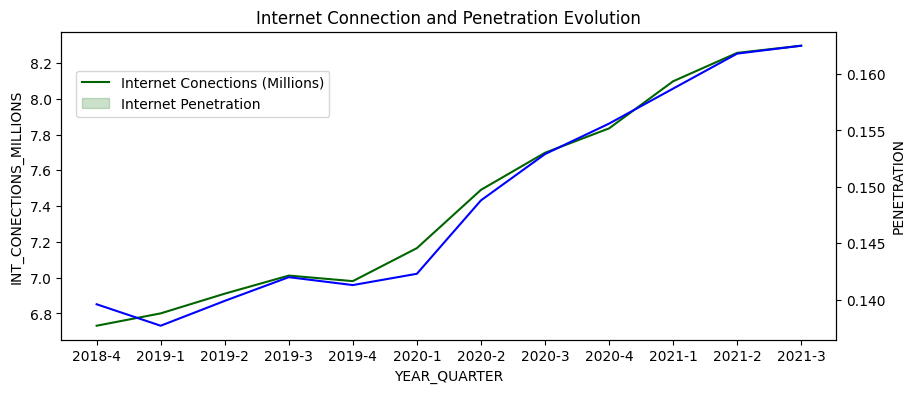

```python
plt.figure(figsize=(10,4))
ax = sns.lineplot(data=fixed_int_nat_penetration, x = 'YEAR_QUARTER', y = 'INT_CONECTIONS_MILLIONS', color = 'darkgreen')
ax2 = plt.twinx()
sns.lineplot(data=fixed_int_nat_penetration, x = 'YEAR_QUARTER', y='PENETRATION', color = 'b', ax=ax2)
ax.figure.legend(labels=['Internet Conections (Millions)','Internet Penetration'], bbox_to_anchor = (0.4,0.8))
plt.title('Internet Connection and Penetration Evolution')
```

```
Forecasted Penetration:
  YEAR_QUARTER  FORECAST_PENETRATION
0       2021-4              0.164721
1       2022-1              0.167203
```

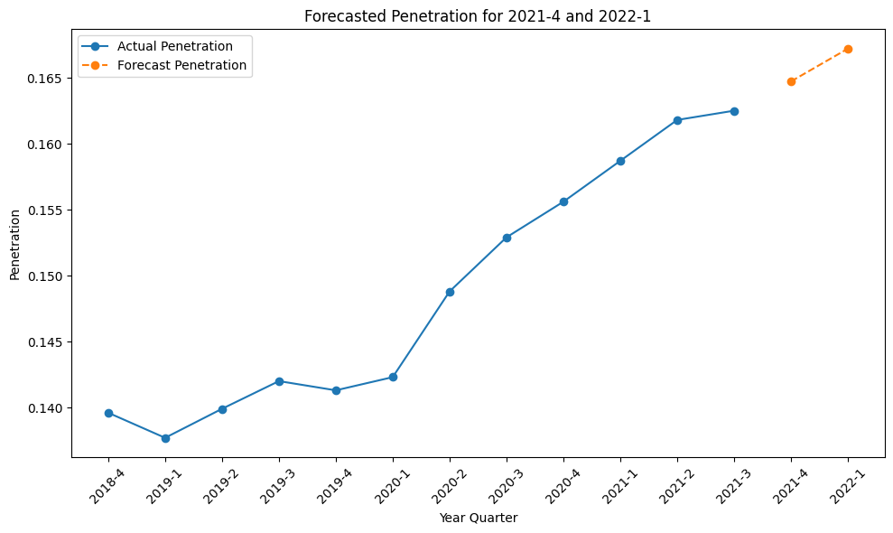

```python
import pandas as pd
from sklearn.linear_model import LinearRegression
import numpy as np

df = fixed_int_nat_penetration

# Convertir YEAR_QUARTER a un valor numérico (secuencial)
df['QUARTER_INDEX'] = range(1, len(df) + 1)

# Separar variables independientes y dependientes
X = df[['QUARTER_INDEX']]  # Índices de los trimestres
y = df['PENETRATION']      # Penetración

# Entrenar un modelo de regresión lineal
model = LinearRegression()
model.fit(X, y)

# Generar índices para 2021-4 y 2022-1
forecast_indices = np.array([[13], [14]])  # Índices de los nuevos trimestres

# Hacer predicciones
forecast_values = model.predict(forecast_indices)

# Mostrar resultados
forecast_df = pd.DataFrame({
    'YEAR_QUARTER': ['2021-4', '2022-1'],
    'FORECAST_PENETRATION': forecast_values
})

print("Forecasted Penetration:")
print(forecast_df)

import matplotlib.pyplot as plt

# Graficar los datos existentes
plt.figure(figsize=(10, 6))
plt.plot(df['YEAR_QUARTER'], df['PENETRATION'], marker='o', label='Actual Penetration')

# Agregar pronósticos al gráfico
plt.plot(forecast_df['YEAR_QUARTER'], forecast_df['FORECAST_PENETRATION'], marker='o', linestyle='--', label='Forecast Penetration')

# Formato del gráfico
plt.xticks(rotation=45)
plt.xlabel('Year Quarter')
plt.ylabel('Penetration')
plt.title('Forecasted Penetration for 2021-4 and 2022-1')
plt.legend()
plt.tight_layout()
plt.show()
```

### Based on the graph above please answer the question 1:

## Please write your response here: La evolución de la penetración es positiva ya que a partir del 1er Q 2020 se ve una tendencia bastante positiva, para poder decir si la penetración actual es alta o baja necesitamos comparar la data con los países vecinos o del mismo índice de crecimiento que colombia.

Haciendo un forecast(LinearRegression) para los siguientes dos trimestres, podemos ver que la penetración sigue en tendencia positiva, siendo 16.47% y 16.72% para 2021-4 y 2022-1 respectivamente. ###

### 2. Does the evolution of the penetration differ for big and small cities? Is the gap increasing or decreasing (take a clear position and support it with numbers resulting from your analysis)

In order to respond this question you shall follow the next steps:

- Understand city population distribution
- Define a threshold and create a label to differentiate big from small cities
- Plot the penetration time series separating big cities from small cities

**2.1** To understand city population, create a DataFrame called "cities_pop" from the original data that shows the maximum population in the series for each **CITY_FULL_ID**. The Dataframe shall have the following schema:

- **'CITY_FULL_ID'**: CITY_FULL_ID as shown in the original dataset
- **'CITY'**: City name as shown in the original dataset
- **'CITY_POPULATION'**: Maximum City Population in the series

*Be aware that two cities might have the same CITY name, while the CITY_FULL_ID is unique per city*

- Find the statistics from "cities_pop[['CITY_FULL_ID','CITY_POPULATION']]" by using the function [*.describe()*](https://pandas.pydata.org/docs/reference/api/pandas.DataFrame.describe.html) and store it as **cities_pop_stats**
- Find and store in the value **threshold_pop** with the population from the last city in the top 5% cities in descending order by population. Use the function *int(round(number_of_cities*0.05,0))* with 0 decimals to define the last city that shall be included in the group.

```python
### Write your Code Here###
cities_pop = fixed_int_city_penetration[['CITY_FULL_ID','CITY','CITY_POPULATION']].groupby(by='CITY_FULL_ID')\
            .max()\
            .sort_values(by='CITY_POPULATION', ascending = False).reset_index()

cities_pop_stats = cities_pop[['CITY_FULL_ID','CITY_POPULATION']].describe()
threshold_pop = int(round(cities_pop.shape[0]*0.05,0))
print('City population statistics:')
display(cities_pop_stats)

print('Top 5 cities:')
display(cities_pop.head(5))
print('The population from the last city in top 5% is: {}'.format(cities_pop.iloc[threshold_pop-1]['CITY_POPULATION']))
display(cities_pop.head(threshold_pop).tail(1))

threshold_pop = cities_pop.iloc[threshold_pop-1]['CITY_POPULATION']
threshold_pop
```

```
City population statistics:
```

|  | CITY_POPULATION |
| --- | --- |
| count | 1.118000e+03 |
| mean | 4.568203e+04 |
| std | 2.686187e+05 |
| min | 2.980000e+02 |
| 25% | 6.843500e+03 |
| 50% | 1.331900e+04 |
| 75% | 2.850325e+04 |
| max | 7.834167e+06 |

```
Top 5 cities:
```

|  | CITY_FULL_ID | CITY | CITY_POPULATION |
| --- | --- | --- | --- |
| 0 | 11-11001 | BOGOTA, D.C. | 7834167 |
| 1 | 5-5001 | MEDELLIN | 2573220 |
| 2 | 76-76001 | CALI | 2264748 |
| 3 | 8-8001 | BARRANQUILLA | 1297082 |
| 4 | 13-13001 | CARTAGENA | 1043926 |

```
The population from the last city in top 5% is: 129710
```

|  | CITY_FULL_ID | CITY | CITY_POPULATION |
| --- | --- | --- | --- |
| 55 | 41-41551 | PITALITO | 129710 |

```
np.int64(129710)
```

```python
### Do not delete evaluation cell##
assert (np.array(cities_pop_stats)[-5:] == np.array([[2.98000000e+02],[6.84350000e+03],[1.33190000e+04],[2.85032500e+04],[7.83416700e+06]])).all(), 'You did not calculate cities_pop_stats or the values are incorrect'
assert threshold_pop == 129710
print('Correct!')
```

```
Correct!
```

**2.2** Calculate DataFrame **fixed_int_city_penetration_cat** to understand service penetration trend for small and big cities:

- Calculate the city category from the DataFrame **fixed_int_city_penetration** calculated in point 1.1 by adding the column fixed_int_city_penetration['CITY_CAT']. Assign the label "large_city" to cities with a population equal or larger than **threshold_pop** from point 2.1 and the label 'small_city' to the other cities. *Hint: You can use np.where or any other method or function to assign conditional values to a DataFrame column*
- Create the aggregated DataFrame **fixed_int_city_penetration_cat** using function groupby() with the following scheme:
  - YEAR_QUARTER: As in the fixed_int_city_penetration DataFrame
  - CITY_CAT: Aggregation of all cities per category ('large_city' or 'small_city') from the fixed_int_city_penetration DataFrame
  - CITY_POPULATION: Sum of the CITY_POPULATION of all cities in each category for each quarter
  - NUMBER_INTERNET_CONECTIONS: Sum of the NUMBER_INTERNET_CONECTIONS of all cities in each category for each quarter
- Calculate the service penetration for each city category *fixed_int_city_penetration_cat['PENETRATION']* by dividing NUMBER_INTERNET_CONECTIONS/CITY_POPULATION. *Hint: Do not calculate Penetration during the groupby aggregation, do it only after the aggregated DataFrame has been calculated*
- Drop columns 'CITY_POPULATION' and 'NUMBER_INTERNET_CONECTIONS' from the DataFrame fixed_int_city_penetration_cat

```python
### Write your Code Here###
fixed_int_city_penetration['CITY_CAT'] = np.where(fixed_int_city_penetration['CITY_POPULATION']>=threshold_pop,'large_city','small_city')
fixed_int_city_penetration.sort_values(by=['CITY_FULL_ID','YEAR_QUARTER'], inplace = True)
display(fixed_int_city_penetration.head(3))
display(fixed_int_city_penetration.tail(3))
fixed_int_city_penetration_cat = fixed_int_city_penetration[['YEAR_QUARTER','CITY_CAT','CITY_POPULATION','NUMBER_INTERNET_CONECTIONS']]\
                                .groupby(by=['YEAR_QUARTER','CITY_CAT']).sum().reset_index()
fixed_int_city_penetration_cat['PENETRATION'] = fixed_int_city_penetration_cat['NUMBER_INTERNET_CONECTIONS']/fixed_int_city_penetration_cat['CITY_POPULATION']
display(fixed_int_city_penetration_cat.tail(4))
fixed_int_city_penetration_cat.drop(columns=['CITY_POPULATION', 'NUMBER_INTERNET_CONECTIONS'], inplace=True)
```

|  | YEAR_QUARTER | CITY_FULL_ID | CITY | TOTAL_SPEED | CITY_POPULATION | NUMBER_INTERNET_CONECTIONS | PENETRATION | CITY_CAT |
| --- | --- | --- | --- | --- | --- | --- | --- | --- |
| 0 | 2018-4 | 11-11001 | BOGOTA, D.C. | 2.258897e+07 | 7412566 | 1876271 | 0.253120 | large_city |
| 1107 | 2019-1 | 11-11001 | BOGOTA, D.C. | 2.444957e+07 | 7592871 | 1874484 | 0.246874 | large_city |
| 2217 | 2019-2 | 11-11001 | BOGOTA, D.C. | 2.646330e+07 | 7592871 | 1890743 | 0.249016 | large_city |

|  | YEAR_QUARTER | CITY_FULL_ID | CITY | TOTAL_SPEED | CITY_POPULATION | NUMBER_INTERNET_CONECTIONS | PENETRATION | CITY_CAT |
| --- | --- | --- | --- | --- | --- | --- | --- | --- |
| 11121 | 2021-1 | 99-99773 | CUMARIBO | 568.0 | 79984 | 20 | 0.000250 | small_city |
| 12233 | 2021-2 | 99-99773 | CUMARIBO | 568.0 | 79984 | 20 | 0.000250 | small_city |
| 13350 | 2021-3 | 99-99773 | CUMARIBO | 823.0 | 79984 | 42 | 0.000525 | small_city |

|  | YEAR_QUARTER | CITY_CAT | CITY_POPULATION | NUMBER_INTERNET_CONECTIONS | PENETRATION |
| --- | --- | --- | --- | --- | --- |
| 20 | 2021-2 | large_city | 30118362 | 6772857 | 0.224875 |
| 21 | 2021-2 | small_city | 20916772 | 1483295 | 0.070914 |
| 22 | 2021-3 | large_city | 30118362 | 6778584 | 0.225065 |
| 23 | 2021-3 | small_city | 20924617 | 1517613 | 0.072528 |

```python
### Do not delete evaluation cell##
assert list(fixed_int_city_penetration_cat.columns) == ['YEAR_QUARTER', 'CITY_CAT', 'PENETRATION'], 'fixed_int_city_penetration_cat was not calculated or the columns are incorrect'
assert float(round(fixed_int_city_penetration_cat[(fixed_int_city_penetration_cat['YEAR_QUARTER']=='2021-2')&(fixed_int_city_penetration_cat['CITY_CAT']=='large_city')]['PENETRATION'],6))==0.224875, 'Service penetration is not correctly aggregated, large cities in 2021-2 shall be 0.223679'
print('Correct!')
```

```
Correct!
```

### Visualize your results

Run the cell below to visualize your results using matplotlib and seaborn

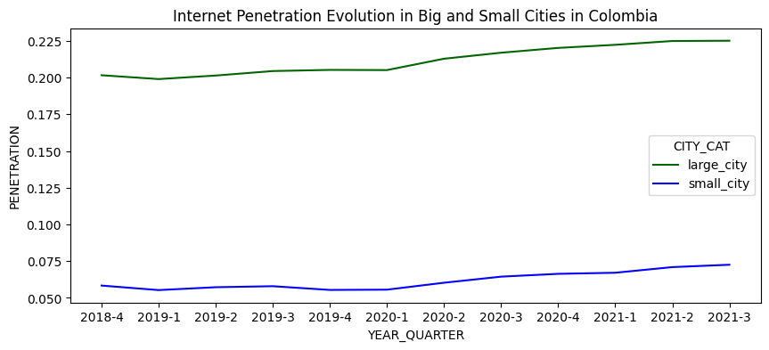

```python
plt.figure(figsize=(10,4))
ax = sns.lineplot(data=fixed_int_city_penetration_cat, x = 'YEAR_QUARTER', y = 'PENETRATION', hue = 'CITY_CAT', palette = ['darkgreen','b'])
plt.title('Internet Penetration Evolution in Big and Small Cities in Colombia')
```

### Based on the graph above please answer the question 2:

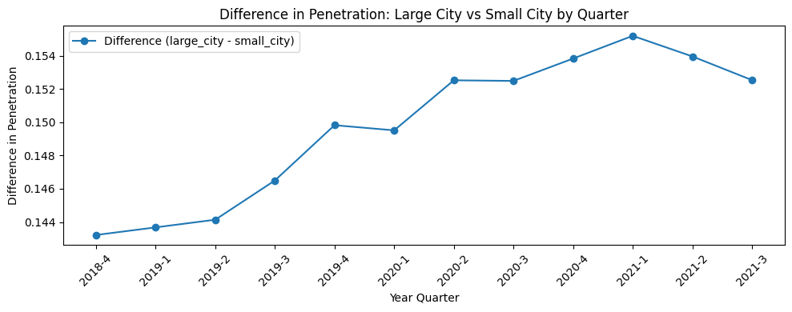

```python
pivot_df = fixed_int_city_penetration_cat.pivot(index='YEAR_QUARTER', columns='CITY_CAT', values='PENETRATION').reset_index()

# Calcular la diferencia
pivot_df['Difference'] = pivot_df['large_city'] - pivot_df['small_city']

# Graficar la tendencia
plt.figure(figsize=(10, 4))
plt.plot(pivot_df['YEAR_QUARTER'], pivot_df['Difference'], marker='o', label='Difference (large_city - small_city)')
plt.xticks(rotation=45)
plt.xlabel('Year Quarter')
plt.ylabel('Difference in Penetration')
plt.title('Difference in Penetration: Large City vs Small City by Quarter')
plt.legend()
plt.tight_layout()
plt.show()
```

## Please write your response here: La evolucion de la penetracion si difiere en gran medida de las grandes ciudades vs ciudades pequeñas, y como podemos observar en el grafico, el gap va creciendo desde 2018 Q4 hasta el 1er Q de 2021, bajando en el 2do y 3er Q del 2021, sin embargo la tendecia es positiva al crecimiento del gap existente.

### 3. How does average internet offered speeds vary between big cities and small cities? Is the gap increasing or decreasing (take a clear position and support it with numbers resulting from your analysis)

Use the same methodology from the previous question, but aggregating by 'TOTAL_SPEED' and 'NUMBER_INTERNET_CONECTIONS' instead of aggregating by population and connections. Once the data is grouped by quarter and city group, calculate the average speed.

**3.1** Calculate **fixed_int_city_speed_cat** DataFrame using fixed_int_city_penetration from item 2.2

- Create DataFrame **fixed_int_city_speed_cat** by aggregating 'YEAR_QUARTER' and 'CITY_CAT' and summing 'TOTAL_SPEED' and 'NUMBER_INTERNET_CONECTIONS' from fixed_int_city_penetration
- Calculate fixed_int_city_speed_cat['AVG_SPEED'] by dividing TOTAL_SPEED BY 'NUMBER_INTERNET_CONECTIONS'
- Drop columns 'TOTAL_SPEED' and 'NUMBER_INTERNET_CONECTIONS'

The final fixed_int_city_speed_cat DataFrame shall have the following schema:

- YEAR_QUARTER
- CITY_CAT
- AVG_SPEED: Average speed for each quarter and city category

```python
fixed_int_city_penetration
```

|  | YEAR_QUARTER | CITY_FULL_ID | CITY | TOTAL_SPEED | CITY_POPULATION | NUMBER_INTERNET_CONECTIONS | PENETRATION | CITY_CAT |
| --- | --- | --- | --- | --- | --- | --- | --- | --- |
| 0 | 2018-4 | 11-11001 | BOGOTA, D.C. | 2.258897e+07 | 7412566 | 1876271 | 0.253120 | large_city |
| 1107 | 2019-1 | 11-11001 | BOGOTA, D.C. | 2.444957e+07 | 7592871 | 1874484 | 0.246874 | large_city |
| 2217 | 2019-2 | 11-11001 | BOGOTA, D.C. | 2.646330e+07 | 7592871 | 1890743 | 0.249016 | large_city |
| 3331 | 2019-3 | 11-11001 | BOGOTA, D.C. | 3.816777e+07 | 7592871 | 1915387 | 0.252261 | large_city |
| 4446 | 2019-4 | 11-11001 | BOGOTA, D.C. | 4.940829e+07 | 7592871 | 1916888 | 0.252459 | large_city |
| ... | ... | ... | ... | ... | ... | ... | ... | ... |
| 8896 | 2020-3 | 99-99773 | CUMARIBO | 7.580000e+02 | 78863 | 39 | 0.000495 | small_city |
| 10009 | 2020-4 | 99-99773 | CUMARIBO | 5.810000e+02 | 78863 | 22 | 0.000279 | small_city |
| 11121 | 2021-1 | 99-99773 | CUMARIBO | 5.680000e+02 | 79984 | 20 | 0.000250 | small_city |
| 12233 | 2021-2 | 99-99773 | CUMARIBO | 5.680000e+02 | 79984 | 20 | 0.000250 | small_city |
| 13350 | 2021-3 | 99-99773 | CUMARIBO | 8.230000e+02 | 79984 | 42 | 0.000525 | small_city |

13351 rows × 8 columns

```python
### Write your Code Here###
fixed_int_city_speed_cat = fixed_int_city_penetration[['YEAR_QUARTER','CITY_CAT','TOTAL_SPEED','NUMBER_INTERNET_CONECTIONS']]\
                                .groupby(by=['YEAR_QUARTER','CITY_CAT']).sum().reset_index()
fixed_int_city_speed_cat['AVG_SPEED'] = fixed_int_city_speed_cat['TOTAL_SPEED']/fixed_int_city_speed_cat['NUMBER_INTERNET_CONECTIONS']
display(fixed_int_city_speed_cat.tail(4))
fixed_int_city_speed_cat.drop(columns=['TOTAL_SPEED', 'NUMBER_INTERNET_CONECTIONS'], inplace=True)
```

|  | YEAR_QUARTER | CITY_CAT | TOTAL_SPEED | NUMBER_INTERNET_CONECTIONS | AVG_SPEED |
| --- | --- | --- | --- | --- | --- |
| 20 | 2021-2 | large_city | 4.149141e+08 | 6772857 | 61.261314 |
| 21 | 2021-2 | small_city | 3.729458e+07 | 1483295 | 25.143062 |
| 22 | 2021-3 | large_city | 4.834253e+08 | 6778584 | 71.316560 |
| 23 | 2021-3 | small_city | 4.402173e+07 | 1517613 | 29.007218 |

```python
### Do not delete evaluation cell##
assert float(round(fixed_int_city_speed_cat[(fixed_int_city_speed_cat['YEAR_QUARTER']=='2018-4')&(fixed_int_city_speed_cat['CITY_CAT']=='large_city')]['AVG_SPEED'],6)) == 10.445674, 'Average speed in large cities in 2018-4 shall be 10.337148'
assert float(round(fixed_int_city_speed_cat[(fixed_int_city_speed_cat['YEAR_QUARTER']=='2021-3')&(fixed_int_city_speed_cat['CITY_CAT']=='small_city')]['AVG_SPEED'],6)) == 29.007218, 'Average speed in small cities in 2021-3 shall be 28.419843'
print('Correct!')
```

```
Correct!
```

### Visualize your results

Run the cell below to visualize your results using matplotlib and seaborn

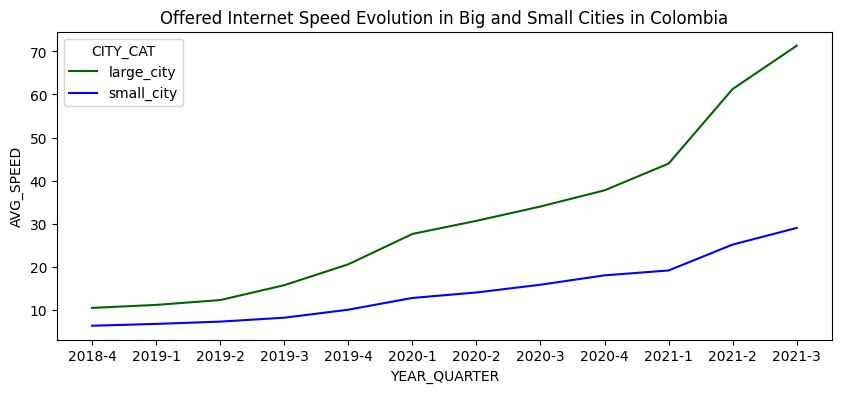

```python
plt.figure(figsize=(10,4))
ax = sns.lineplot(data=fixed_int_city_speed_cat, x = 'YEAR_QUARTER', y = 'AVG_SPEED', hue = 'CITY_CAT', palette = ['darkgreen','b'])
plt.title('Offered Internet Speed Evolution in Big and Small Cities in Colombia')
```

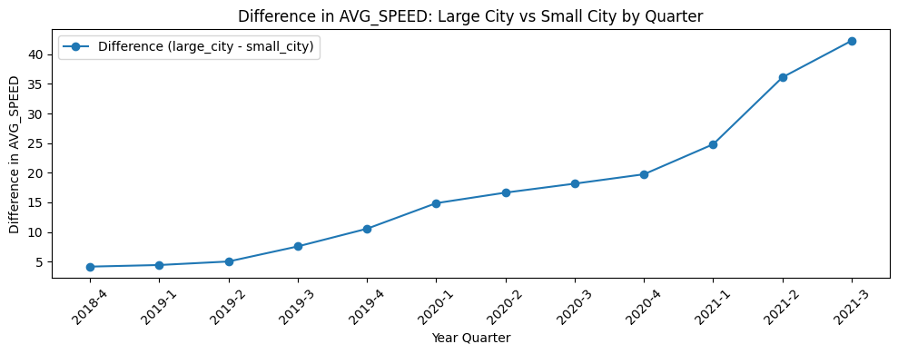

```python
pivot_df = fixed_int_city_speed_cat.pivot(index='YEAR_QUARTER', columns='CITY_CAT', values='AVG_SPEED').reset_index()

# Calcular la diferencia
pivot_df['Difference'] = pivot_df['large_city'] - pivot_df['small_city']

# Graficar la tendencia
plt.figure(figsize=(10, 4))
plt.plot(pivot_df['YEAR_QUARTER'], pivot_df['Difference'], marker='o', label='Difference (large_city - small_city)')
plt.xticks(rotation=45)
plt.xlabel('Year Quarter')
plt.ylabel('Difference in AVG_SPEED')
plt.title('Difference in AVG_SPEED: Large City vs Small City by Quarter')
plt.legend()
plt.tight_layout()
plt.show()
```

### Based on the graph above please answer the question 3:

## Please write your response here: La diferencia se nota abruptamente a medida que avanzan los trimestres, mientras crece la penetracion y las conexiones, tambien aumenta la necesidad de tener una major velocidad de conexion, aun asi es notable que la velocidad crece en las ciudades grandes esto puede deberse a la saturacion de ancho de banda a medida que crece la cantidad de conexiones###

### 4. Is the distribution between internet service providers different in big cities and small cities? What are the possible implications of that difference?

Data has shown that there is a significant gap in penetration and offered speeds between small cities and big cities. This difference might be explained because the biggest internet providers might not be interested in serving small cities in rural areas, and hence the quality and coverage of the offer migth be inferior in small cities. Follow the next steps to complete de task:

**4.1** Large cities:

- Add the column 'CITY_CAT' to the original dataframe (*fixed_internet_base*) using the same method that you used to solve item 2.2 and the same separation threshold (**threshold_pop**) for large and small cities.
- Create the DataFrame **vendor_share_large_cities** by filtering from *fixed_internet_base* the registries where fixed_internet_base['YEAR_QUARTER'] == '2021-3', and fixed_internet_base['CITY_CAT'] == 'large_city'. Include only the following columns: 'INTERNET_PROVIDER' and 'NUMBER_INTERNET_CONECTIONS'
- Aggregate the resulting **vendor_share_large_cities** DataFrame by 'INTERNET_PROVIDER' using groupby() function. Store the result in the same **vendor_share_large_cities**. Sort values by the aggregated 'NUMBER_INTERNET_CONECTIONS' in descending order and reset index.
- Select the 9 largest Internet Providers and **group all other vendors in a row called "Others"**
- Calculate column *vendor_share_large_cities['SHARE_LARGE_CITIES']* with the percentage participation or market share for each Internet Provider in Large cities.
- Drop the column 'NUMBER_INTERNET_CONECTIONS'

Your resulting DataFrame shall have the following schema:

- 'INTERNET_PROVIDER': Internet providers as provided in the original dataset
- 'SHARE_LARGE_CITIES': % share of connections from each Internet Providers in Large Cities

Your DataFrame shall have 10 rows: 9 rows with the largest Internet Vendors for large cities and one row with the market share for the remaining providers called "Others".

```python
### Write your Code Here###
fixed_internet_base['CITY_CAT'] = np.where(fixed_internet_base['CITY_POPULATION']>=threshold_pop,'large_city','small_city')

display(fixed_internet_base.head(3))
display(fixed_internet_base.tail(3))

vendor_share_large_cities = fixed_internet_base[(fixed_internet_base['YEAR_QUARTER']== '2021-3') & (fixed_internet_base['CITY_CAT']== 'large_city')][['INTERNET_PROVIDER','NUMBER_INTERNET_CONECTIONS']]

#print(vendor_share_large_cities.head(5))

# Aggregate by 'INTERNET_PROVIDER' & Sort by 'NUMBER_INTERNET_CONECTIONS' in descending order
vendor_share_large_cities = vendor_share_large_cities.groupby(by='INTERNET_PROVIDER', as_index=False).sum().sort_values(by='NUMBER_INTERNET_CONECTIONS', ascending = False).reset_index(drop=True)

# Handle top 9 providers and group others
top_providers = vendor_share_large_cities[:9]  # Top 9 providers
others = vendor_share_large_cities[9:]        # All others

# Aggregate "Others" into a single row
if not others.empty:
    others_row = pd.DataFrame({
        'INTERNET_PROVIDER': ['Others'],
        'NUMBER_INTERNET_CONECTIONS': [others['NUMBER_INTERNET_CONECTIONS'].sum()]
    })
    vendor_share_large_cities = pd.concat([top_providers, others_row], ignore_index=True)

# Calculate market share as a percentage
total_connections = vendor_share_large_cities['NUMBER_INTERNET_CONECTIONS'].sum()
vendor_share_large_cities['SHARE_LARGE_CITIES'] = (vendor_share_large_cities['NUMBER_INTERNET_CONECTIONS'] / total_connections)

# Drop 'NUMBER_INTERNET_CONECTIONS' column
vendor_share_large_cities.drop(columns=['NUMBER_INTERNET_CONECTIONS'], inplace=True)

# Display the resulting DataFrame
print(vendor_share_large_cities)
```

|  | YEAR | QUARTER | CITY_FULL_ID | DEPARTMENT | CITY | TECHNOLOGY | INTERNET_PROVIDER | DOWN_SPEED | CITY_POPULATION | NUMBER_INTERNET_CONECTIONS | YEAR_QUARTER | TOTAL_SPEED | CITY_CAT |
| --- | --- | --- | --- | --- | --- | --- | --- | --- | --- | --- | --- | --- | --- |
| 0 | 2018 | 4 | 11-11001 | BOGOTA | BOGOTA, D.C. | CABLE | COMPUSEB SOLUTIONS SAS | 2.0 | 7412566 | 30 | 2018-4 | 60.0 | large_city |
| 1 | 2018 | 4 | 11-11001 | BOGOTA | BOGOTA, D.C. | CABLE | COMPUSEB SOLUTIONS SAS | 4.0 | 7412566 | 3 | 2018-4 | 12.0 | large_city |
| 2 | 2018 | 4 | 11-11001 | BOGOTA | BOGOTA, D.C. | CABLE | COMPUSEB SOLUTIONS SAS | 6.0 | 7412566 | 4 | 2018-4 | 24.0 | large_city |

|  | YEAR | QUARTER | CITY_FULL_ID | DEPARTMENT | CITY | TECHNOLOGY | INTERNET_PROVIDER | DOWN_SPEED | CITY_POPULATION | NUMBER_INTERNET_CONECTIONS | YEAR_QUARTER | TOTAL_SPEED | CITY_CAT |
| --- | --- | --- | --- | --- | --- | --- | --- | --- | --- | --- | --- | --- | --- |
| 461662 | 2021 | 3 | 99-99773 | VICHADA | CUMARIBO | SATELITAL | BANSAT S.A. | 7.0 | 79984 | 1 | 2021-3 | 7.0 | small_city |
| 461663 | 2021 | 3 | 99-99773 | VICHADA | CUMARIBO | SATELITAL | RED DE INGENIER�A SAS - INRED | 1.0 | 79984 | 4 | 2021-3 | 4.0 | small_city |
| 461664 | 2021 | 3 | 99-99773 | VICHADA | CUMARIBO | SATELITAL | SKYNET DE COLOMBIA S.A.S. E.S.P | 6.0 | 79984 | 1 | 2021-3 | 6.0 | small_city |

```
                                  INTERNET_PROVIDER  SHARE_LARGE_CITIES
0               COMUNICACION CELULAR S A COMCEL S A            0.425662
1                   UNE EPM TELECOMUNICACIONES S.A.            0.222105
2           COLOMBIA TELECOMUNICACIONES S.A. E.S.P.            0.151276
3  EMPRESA DE TELECOMUNICACIONES DE BOGOTA S.A. ESP            0.101456
4           EMPRESAS MUNICIPALES DE CALI EICE E.S.P            0.014896
5                             DIRECTV COLOMBIA LTDA            0.014243
6                             H V TELEVISION S.A.S.            0.008903
7                                       EDATEL S.A.            0.003226
8                    DIALNET DE COLOMBIA S.A   ESP.            0.002761
9                                            Others            0.055472
```

```python
### Do not delete evaluation cell##
assert list(vendor_share_large_cities.columns)==['INTERNET_PROVIDER','SHARE_LARGE_CITIES'], 'DataFrame Columns are not correct'
assert vendor_share_large_cities.shape == (10, 2), 'DataFrame shape is not correct'
assert list(vendor_share_large_cities.iloc[0:3,0])==['COMUNICACION CELULAR S A COMCEL S A', 'UNE EPM TELECOMUNICACIONES S.A.', 'COLOMBIA TELECOMUNICACIONES S.A. E.S.P.']
assert float(round(vendor_share_large_cities.iloc[0,1],6))==0.425662, 'Market share is not correct, COMCEL market share shall be 0.425662'
assert float(round(vendor_share_large_cities.iloc[9,1],6))==0.055472, 'Market share is not correct, Others market share shall be 0.055472'
print('Correct!')
```

```
Correct!
```

**4.2** Small cities:

- Create the DataFrame **vendor_share_small_cities** by filtering from *fixed_internet_base* the registries where fixed_internet_base['YEAR_QUARTER'] == '2021-3', and fixed_internet_base['CITY_CAT'] == 'small_city'. Include only the following columns: 'INTERNET_PROVIDER' and 'NUMBER_INTERNET_CONECTIONS'
- Aggregate the resulting **vendor_share_small_cities** DataFrame by 'INTERNET_PROVIDER' using groupby() function. Store the result in the same **vendor_share_large_cities**. Sort values by the aggregated 'NUMBER_INTERNET_CONECTIONS' in descending order and reset index.
- Select the 9 largest Internet Providers and **group all other vendors in a row called "Others"**
- Calculate column *vendor_share_small_cities['SHARE_LARGE_CITIES']* with the percentage participation or market share for each Internet Provider in Small cities.
- Drop the column 'NUMBER_INTERNET_CONECTIONS'

Your resulting DataFrame shall have the following schema:

- 'INTERNET_PROVIDER': Internet providers as provided in the original dataset
- 'SHARE_SMALL_CITIES': % share of connections from each Internet Providers in Small Cities

Your DataFrame shall have 10 rows: 9 rows with the largest Internet Vendors for small cities and one row with the market share for the remaining providers called "Others".

```python
### Write your Code Here###
vendor_share_small_cities = fixed_internet_base[(fixed_internet_base['YEAR_QUARTER']== '2021-3') & (fixed_internet_base['CITY_CAT']== 'small_city')][['INTERNET_PROVIDER','NUMBER_INTERNET_CONECTIONS']]

# Aggregate by 'INTERNET_PROVIDER' & Sort by 'NUMBER_INTERNET_CONECTIONS' in descending order
vendor_share_small_cities = vendor_share_small_cities.groupby(by='INTERNET_PROVIDER', as_index=False).sum().sort_values(by='NUMBER_INTERNET_CONECTIONS', ascending = False).reset_index(drop=True)

# Handle top 9 providers and group others
top_providers = vendor_share_small_cities[:9]  # Top 9 providers
others = vendor_share_small_cities[9:]        # All others

# Aggregate "Others" into a single row
if not others.empty:
    others_row = pd.DataFrame({
        'INTERNET_PROVIDER': ['Others'],
        'NUMBER_INTERNET_CONECTIONS': [others['NUMBER_INTERNET_CONECTIONS'].sum()]
    })
    vendor_share_small_cities = pd.concat([top_providers, others_row], ignore_index=True)

# Calculate market share as a percentage
total_connections = vendor_share_small_cities['NUMBER_INTERNET_CONECTIONS'].sum()
vendor_share_small_cities['SHARE_SMALL_CITIES'] = (vendor_share_small_cities['NUMBER_INTERNET_CONECTIONS'] / total_connections)

# Drop 'NUMBER_INTERNET_CONECTIONS' column
vendor_share_small_cities.drop(columns=['NUMBER_INTERNET_CONECTIONS'], inplace=True)
vendor_share_small_cities = vendor_share_small_cities.sort_values(by='SHARE_SMALL_CITIES', ascending = False).reset_index(drop=True)

# Display the resulting DataFrame
print(vendor_share_small_cities)
```

```
                         INTERNET_PROVIDER  SHARE_SMALL_CITIES
0                                   Others            0.343441
1      COMUNICACION CELULAR S A COMCEL S A            0.194343
2          UNE EPM TELECOMUNICACIONES S.A.            0.137773
3                              EDATEL S.A.            0.096737
4  COLOMBIA TELECOMUNICACIONES S.A. E.S.P.            0.095898
5                    DIRECTV COLOMBIA LTDA            0.045664
6           DIALNET DE COLOMBIA S.A   ESP.            0.029565
7                           RURALINK S.A.S            0.021702
8                    H V TELEVISION S.A.S.            0.018430
9             ENERGIA INTEGRAL ANDINA S.A.            0.016447
```

```python
### Do not delete evaluation cell##
assert list(vendor_share_small_cities.columns)==['INTERNET_PROVIDER','SHARE_SMALL_CITIES'], 'DataFrame Columns are not correct'
assert vendor_share_small_cities.shape == (10, 2), 'DataFrame shape is not correct'
assert list(vendor_share_small_cities.iloc[0:3,0])==['Others', 'COMUNICACION CELULAR S A COMCEL S A', 'UNE EPM TELECOMUNICACIONES S.A.']
assert float(round(vendor_share_small_cities.iloc[1,1],6))==0.194343, 'Market share is not correct, COMCEL market share shall be 0.194343'
assert float(round(vendor_share_small_cities.iloc[0,1],6))==0.343441, 'Market share is not correct, Others market share shall be 0.343441'
print('Correct!')
```

```
Correct!
```

### Visualize your results

Run the cell below to visualize your results using matplotlib and seaborn

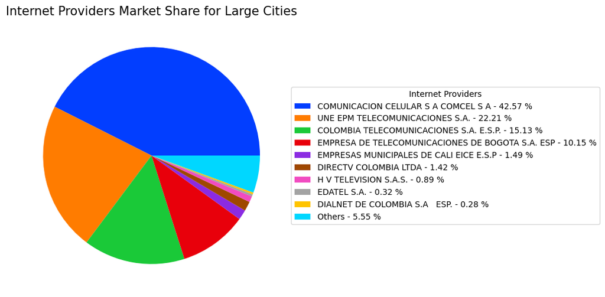

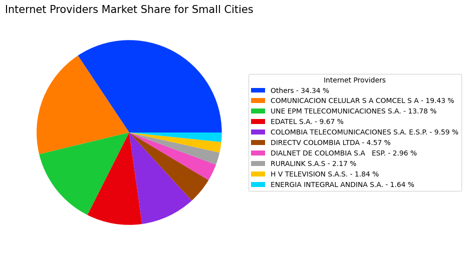

```python
fig, ax = plt.subplots(figsize=(6, 6), subplot_kw=dict(aspect="equal"))
wedges, autotexts = plt.pie(data=vendor_share_large_cities, x = 'SHARE_LARGE_CITIES', labels = None, colors = sns.color_palette("bright"))
labels = ['{0} - {1:1.2f} %'.format(i,j) for i,j in zip(vendor_share_large_cities['INTERNET_PROVIDER'], vendor_share_large_cities['SHARE_LARGE_CITIES']*100)]
ax.legend(wedges, labels,
          title="Internet Providers",
          loc="center left",
          bbox_to_anchor=(1, 0, 0.5, 1))


plt.setp(autotexts, size=8, weight="bold")
plt.title('Internet Providers Market Share for Large Cities', fontsize = 15)
plt.show()

fig, ax2 = plt.subplots(figsize=(6, 6), subplot_kw=dict(aspect="equal"))
wedges, autotexts = plt.pie(data=vendor_share_small_cities, x = 'SHARE_SMALL_CITIES', labels = None, colors = sns.color_palette("bright"))
labels = ['{0} - {1:1.2f} %'.format(i,j) for i,j in zip(vendor_share_small_cities['INTERNET_PROVIDER'], vendor_share_small_cities['SHARE_SMALL_CITIES']*100)]
ax2.legend(wedges, labels,
          title="Internet Providers",
          loc="center left",
          bbox_to_anchor=(1, 0, 0.5, 1))


plt.setp(autotexts, size=8, weight="bold")
plt.title('Internet Providers Market Share for Small Cities', fontsize = 15)
plt.show()
```

### Based on the graph above please answer the question 4:

## Please write your response here: Ciudades Grandes:

Dominio de pocos proveedores principales: "COMUNICACIÓN CELULAR S A COMCEL S A" lidera con un 42.57%. Otros grandes actores incluyen "UNE EPM TELECOMUNICACIONES S.A." (22.21%) y "COLOMBIA TELECOMUNICACIONES S.A. E.S.P." (15.13%). "Otros" representa solo el 5.55%, lo que sugiere un mercado altamente concentrado.

Ciudades Pequeñas: Mayor diversidad de proveedores: "COMUNICACIÓN CELULAR S A COMCEL S A" tiene una participación más reducida (19.43%), mientras que "Otros" lidera con un 34.34%. Proveedores más pequeños, como "EDATEL S.A." (9.67%) y "RURALINK S.A.S." (2.17%), tienen mayor relevancia, reflejando un mercado más fragmentado.

Las posibles implicaciones de esta diferencia puede ser la estrategia de los proveedores de servicios en penetrar mejor las grandes ciudades donde se presentaría mayor facturación y mayor ROI al hacer algún tipo de inversión en infraestructura o antenas para mejorar la experiencia.

### 5. Previous questions have shown that two very different groups of cities can be separated by population (size of the city), Can cities be grouped or clustered based on other indicators in the dataset? What are the characteristics from each cluster?

This question can be answered by running an unsupervised clustering algorithm using features from the original dataset. The clustering will be done using normalized data from the following columns in the original dataset:

- CITY_POPULATION
- NUMBER_INTERNET_CONECTIONS
- PENETRATION
- AVG_SPEED
- % of connections per technology type

The first 3 features are already calculated in the **fixed_int_city_penetration** DataFrame from point 2.2. The remaining two have to be calculated:

**5.1** Create **fixed_int_city_panel** DataFrame that will be entered into the k-means algorithm following the next steps:

- Create the DataFrame **fixed_int_city_panel** by filtering from *fixed_int_city_penetration* the registries where fixed_int_city_penetration['YEAR_QUARTER'] == '2021-3'
- Calculate fixed_int_city_panel['AVG_SPEED'] dividing 'TOTAL_SPEED' by 'NUMBER_INTERNET_CONECTIONS'
- Drop columns YEAR_QUARTER, TOTAL_SPEED, CITY_CAT and reset index. The resulting **fixed_int_city_panel** DataFrame shall have the following schema:
  - CITY_FULL_ID
  - CITY
  - CITY_POPULATION
  - NUMBER_INTERNET_CONECTIONS
  - PENETRATION
  - AVG_SPEED

```python
### Write your Code Here###
fixed_int_city_panel = fixed_int_city_penetration[fixed_int_city_penetration['YEAR_QUARTER']=='2021-3'] #[['YEAR_QUARTER','TOTAL_SPEED','CITY_FULL_ID','CITY','CITY_POPULATION','NUMBER_INTERNET_CONECTIONS','PENETRATION']]

fixed_int_city_panel['AVG_SPEED'] = fixed_int_city_panel['TOTAL_SPEED']/fixed_int_city_panel['NUMBER_INTERNET_CONECTIONS']

fixed_int_city_panel.drop(columns=['YEAR_QUARTER', 'TOTAL_SPEED', 'CITY_CAT'], inplace=True)
```

```python
### Do not delete evaluation cell##
assert fixed_int_city_panel.shape == (1117,6), 'The shape of fixed_int_city_panel is not correct or the DataFrame does not exist'
assert list(fixed_int_city_panel.columns) == ['CITY_FULL_ID', 'CITY', 'CITY_POPULATION', 'NUMBER_INTERNET_CONECTIONS','PENETRATION', 'AVG_SPEED'], 'The columns from the fixed_int_city_panel are not correct'
assert [round(i,6)  if type(i) is np.float64 else i for i in list(fixed_int_city_panel[fixed_int_city_panel['CITY_FULL_ID']=='11-11001'].iloc[0])] == ['11-11001', 'BOGOTA, D.C.', 7834167, 2157079, 0.275342, 84.867203], 'Values for Bogota are incorrect, they should be [11-11001, BOGOTA, D.C., 7834167, 2157079, 0.275342, 84.867203]'
assert [round(i,6)  if type(i) is np.float64 else i for i in list(fixed_int_city_panel[fixed_int_city_panel['CITY_FULL_ID']=='8-8549'].iloc[0])] == ['8-8549', 'PIOJO', 7216, 10, 0.001386, 27.9], 'Values for Piojo are incorrect, they should be [8-8549, PIOJO, 7216, 10, 0.001386, 27.9]'
print('Correct!')
```

```
Correct!
```

**5.2** Calculate % of connections per type for each city Create the DataFrame **fixed_cat_tech_city** with the percentage of connections per type, in order to do so, the original dataset (*fixed_internet_base*) shall be used. Follow the next steps:

- Create fixed_cat_tech_city by filtering from *fixed_internet_base* the registries where fixed_internet_base['YEAR_QUARTER'] == '2021-3', include only the columns 'CITY_FULL_ID', 'TECHNOLOGY', and 'NUMBER_INTERNET_CONECTIONS'
- Create the column fixed_cat_tech_city['CABLE'] that is equal to the number of connections **if the column 'TECHNOLOGY' contains the words 'CABLE' or 'HFC'** or else 0. **Hint: You can use np.where and the function str.contains (ie. fixed_cat_tech_city['TECHNOLOGY'].str.contains('CABLE'))**
- Create the column fixed_cat_tech_city['FTTX'] that is equal to the number of connections **if the column 'TECHNOLOGY' contains the words 'FIBER TO THE'** or else 0.
- Create the column fixed_cat_tech_city['SATELITAL'] that is equal to the number of connections **if the column 'TECHNOLOGY' contains the words 'SATELITAL'** or else 0.
- Create the column fixed_cat_tech_city['COPPER'] that is equal to the number of connections **if the column 'TECHNOLOGY' contains the words 'DSL'** or else 0.
- **Aggregate the results per CITY_FULL_ID using groupby and aggregation function sum for columns 'NUMBER_INTERNET_CONECTIONS', 'CABLE', 'FTTX', 'SATELITAL', 'COPPER'. Save the results in the** **fixed_cat_tech_city**
- Calculate the column fixed_cat_tech_city['%_CABLE'] dividing the column fixed_cat_tech_city['CABLE'] by the column fixed_cat_tech_city['NUMBER_INTERNET_CONECTIONS'] for each city
- Calculate columns '%_FTTX', '%_SATELITAL', and '%_COPPER' using the same methodology used for %_CABLE
- Drop columns 'NUMBER_INTERNET_CONECTIONS', 'CABLE', 'FTTX', 'SATELITAL', 'COPPER' and reset index

Your resulting **fixed_cat_tech_city** DataFrame shall include the following columns:

- CITY_FULL_ID
- CABLE_%
- FTTX_%
- SATELITAL_%
- COPPER_%

```python
fixed_cat_tech_city['TECHNOLOGY'].unique()
```

```
array(['CABLE', 'FIBER TO THE BUILDING O FIBER',
       'FIBER TO THE CABINET (FTTC)', 'FIBER TO THE HOME (FTTH)',
       'FIBER TO THE NODE (FTTN)', 'FIBER TO THE PREMISES',
       'FIBER TO THE X (FTTX)', 'HYBRID FIBER COAXIAL (HFC)',
       'OTRAS TECNOLOG�AS FIJAS', 'OTRAS TECNOLOG�AS INAL�MBRICAS',
       'SATELITAL', 'WIFI', 'WIMAX', 'XDSL',
       'FIBER TO THE ANTENNA (FTTA)'], dtype=object)
```

```python
### Write your Code Here###

#### Calculate number of connections per technology (Example for Cable) ###
fixed_cat_tech_city = fixed_internet_base[fixed_internet_base['YEAR_QUARTER']=='2021-3']
fixed_cat_tech_city['CABLE'] = np.where((fixed_cat_tech_city['TECHNOLOGY'].str.contains('CABLE') | fixed_cat_tech_city['TECHNOLOGY'].str.contains('HFC')),fixed_cat_tech_city['NUMBER_INTERNET_CONECTIONS'],0)

### Replicatie for other technologies ###
#...
fixed_cat_tech_city['FTTX'] = np.where(fixed_cat_tech_city['TECHNOLOGY'].str.contains('FIBER TO THE'),fixed_cat_tech_city['NUMBER_INTERNET_CONECTIONS'],0)
fixed_cat_tech_city['SATELITAL'] = np.where(fixed_cat_tech_city['TECHNOLOGY'].str.contains('SATELITAL'),fixed_cat_tech_city['NUMBER_INTERNET_CONECTIONS'],0)
fixed_cat_tech_city['COPPER'] = np.where(fixed_cat_tech_city['TECHNOLOGY'].str.contains('DSL'),fixed_cat_tech_city['NUMBER_INTERNET_CONECTIONS'],0)
```

```python
fixed_cat_tech_city
```

[output not shown]

```python
### Group by 'CITY_FULL_ID' ###
fixed_cat_tech_city = fixed_cat_tech_city[['CITY_FULL_ID','NUMBER_INTERNET_CONECTIONS','CABLE','FTTX','SATELITAL','COPPER']].groupby(by=['CITY_FULL_ID']).sum().reset_index()


#### Calculate share per technology (Example for Cable) ###
fixed_cat_tech_city['CABLE_%'] = fixed_cat_tech_city['CABLE'] / fixed_cat_tech_city['NUMBER_INTERNET_CONECTIONS']

### Replicatie for other technologies ###
#...
fixed_cat_tech_city['FTTX_%'] = fixed_cat_tech_city['FTTX'] / fixed_cat_tech_city['NUMBER_INTERNET_CONECTIONS']
fixed_cat_tech_city['SATELITAL_%'] = fixed_cat_tech_city['SATELITAL'] / fixed_cat_tech_city['NUMBER_INTERNET_CONECTIONS']
fixed_cat_tech_city['COPPER_%'] = fixed_cat_tech_city['COPPER'] / fixed_cat_tech_city['NUMBER_INTERNET_CONECTIONS']

### Drop columns ###
fixed_cat_tech_city.drop(columns=['NUMBER_INTERNET_CONECTIONS', 'CABLE', 'FTTX', 'SATELITAL', 'COPPER'], inplace=True)
```

```python
### Do not delete evaluation cell##
assert fixed_cat_tech_city.shape == (1117,5), 'The shape of fixed_int_city_panel is not correct or the DataFrame does not exist'
assert list(fixed_cat_tech_city.columns) == ['CITY_FULL_ID', 'CABLE_%', 'FTTX_%', 'SATELITAL_%', 'COPPER_%'], 'The columns from the fixed_int_city_panel are not correct'
assert [round(i,6)  if type(i) is np.float64 else i for i in list(fixed_cat_tech_city[fixed_cat_tech_city['CITY_FULL_ID']=='11-11001'].iloc[0])]  == ['11-11001', 0.595995, 0.313013, 4.6e-05, 0.087355], 'Values for Bogota are incorrect, they should be [11-11001, 0.595995, 0.313013, 4.6e-05, 0.087355]'
assert [round(i,6)  if type(i) is np.float64 else i for i in list(fixed_cat_tech_city[fixed_cat_tech_city['CITY_FULL_ID']=='8-8549'].iloc[0])] == ['8-8549', 0.1, 0.2, 0.1, 0.1], 'Values for Piojo are incorrect, they should be [8-8549, 0.1, 0.2, 0.1, 0.1]'
print('Correct!')
```

```
Correct!
```

**5.3** Merge **fixed_int_city_panel** and **fixed_cat_tech_city** DataFrames

Make a **left join** from **fixed_int_city_panel** to **fixed_cat_tech_city** DataFrames on 'CITY_FULL_ID', store the result in **fixed_int_city_panel** DataFrame

```python
### Write your Code Here###
fixed_int_city_panel = fixed_int_city_panel.merge(fixed_cat_tech_city, on='CITY_FULL_ID', how='left')
```

```python
### Do not delete evaluation cell##
assert fixed_int_city_panel.shape == (1117,10), 'The shape of fixed_int_city_panel is not correct or the DataFrame does not exist'
assert list(fixed_int_city_panel.columns) == ['CITY_FULL_ID', 'CITY', 'CITY_POPULATION', 'NUMBER_INTERNET_CONECTIONS','PENETRATION', 'AVG_SPEED', 'CABLE_%', 'FTTX_%', 'SATELITAL_%', 'COPPER_%'], 'The columns from the fixed_int_city_panel are not correct'
assert [round(i,6)  if type(i) is np.float64 else i for i in list(fixed_int_city_panel[fixed_int_city_panel['CITY_FULL_ID']=='11-11001'].iloc[0])] == ['11-11001', 'BOGOTA, D.C.', 7834167, 2157079, 0.275342, 84.867203, 0.595995, 0.313013, 4.6e-05, 0.087355], 'Values for Bogota are incorrect, they should be [11-11001, BOGOTA, D.C., 7834167, 2157079, 0.275342, 84.867203, 0.595995, 0.313013, 4.6e-05, 0.087355]'
assert [round(i,6)  if type(i) is np.float64 else i for i in list(fixed_int_city_panel[fixed_int_city_panel['CITY_FULL_ID']=='8-8549'].iloc[0])] == ['8-8549', 'PIOJO', 7216, 10, 0.001386, 27.9, 0.1, 0.2, 0.1, 0.1], 'Values for Piojo are incorrect, they should be [8-8549, PIOJO, 7216, 10, 0.001386, 27.9,  0.1, 0.2, 0.1, 0.1]'
print('Correct!')
```

```
Correct!
```

**5.4** Run the k-mean analysis Once the final city panel is available, two preparation tasks shall be completed:

- Extract the data-columns that shall be included in the clustering analysis
- Normalize data (city population is in millions, while penetration is a percentage) and convert to np.array

Once the data is ready in the np array, the k-means analysis can be run using vq.means

Finally, the clusters can be characterized by understanding the mean of the clustering variables and the relationship between variables can be plotted using seaborn pairplot.

```python
# Run the code below to complete the clustering analyisis:

# Extract columns that shall be used for the clustering analysis:
df = fixed_int_city_panel.drop(columns=['CITY','CITY_FULL_ID'])
# Normalize values and convert to np.array
array_k_means = np.array((df-df.mean())/df.std())

# Define k and run k-means clustering
k = 4
centers_vq, distortion_vq = vq.kmeans(array_k_means, k)
clustering_vq, _ = vq.vq(array_k_means, centers_vq)

# Merge the cluster id to the city panel
fixed_int_city_panel['clustering_vq'] = clustering_vq

# Characterize clusters
cluster_characterization = fixed_int_city_panel[['CITY_FULL_ID','CITY_POPULATION','NUMBER_INTERNET_CONECTIONS','PENETRATION','AVG_SPEED','CABLE_%','FTTX_%','SATELITAL_%','COPPER_%','clustering_vq']]\
                            .groupby(['clustering_vq']).agg({'CITY_FULL_ID':'count','CITY_POPULATION':'mean','NUMBER_INTERNET_CONECTIONS':'mean','PENETRATION':'mean','AVG_SPEED':'mean','CABLE_%':'mean','FTTX_%': 'mean','SATELITAL_%':'mean', 'COPPER_%':'mean'})\
                            .sort_values(by='PENETRATION').reset_index()
```

#### Show mean data from each cluster:

```python
display(cluster_characterization)
```

|  | clustering_vq | CITY_FULL_ID | CITY_POPULATION | NUMBER_INTERNET_CONECTIONS | PENETRATION | AVG_SPEED | CABLE_% | FTTX_% | SATELITAL_% | COPPER_% |
| --- | --- | --- | --- | --- | --- | --- | --- | --- | --- | --- |
| 0 | 0 | 487 | 14885.349076 | 547.211499 | 0.026550 | 18.471424 | 0.027048 | 0.799436 | 0.015323 | 0.040269 |
| 1 | 1 | 354 | 19518.494350 | 789.686441 | 0.033540 | 10.651443 | 0.168258 | 0.183690 | 0.065896 | 0.068287 |
| 2 | 3 | 155 | 29076.225806 | 2384.593548 | 0.077222 | 8.939064 | 0.040270 | 0.165297 | 0.005299 | 0.679815 |
| 3 | 2 | 121 | 267582.247934 | 60996.231405 | 0.189733 | 54.571322 | 0.651570 | 0.146888 | 0.001652 | 0.121271 |

```python
fixed_int_city_panel[fixed_int_city_panel['CITY']=='MANIZALES'] #.to_excel('cluster2.xlsx',index=False) #.sort_values(by='FTTX_%', ascending = True)
```

|  | CITY_FULL_ID | CITY | CITY_POPULATION | NUMBER_INTERNET_CONECTIONS | PENETRATION | AVG_SPEED | CABLE_% | FTTX_% | SATELITAL_% | COPPER_% | clustering_vq |
| --- | --- | --- | --- | --- | --- | --- | --- | --- | --- | --- | --- |
| 170 | 17-17001 | MANIZALES | 450074 | 97397 | 0.216402 | 64.135518 | 0.911856 | 0.042927 | 0.000031 | 0.023779 | 2 |

#### Plot distribution and relationship between different variables

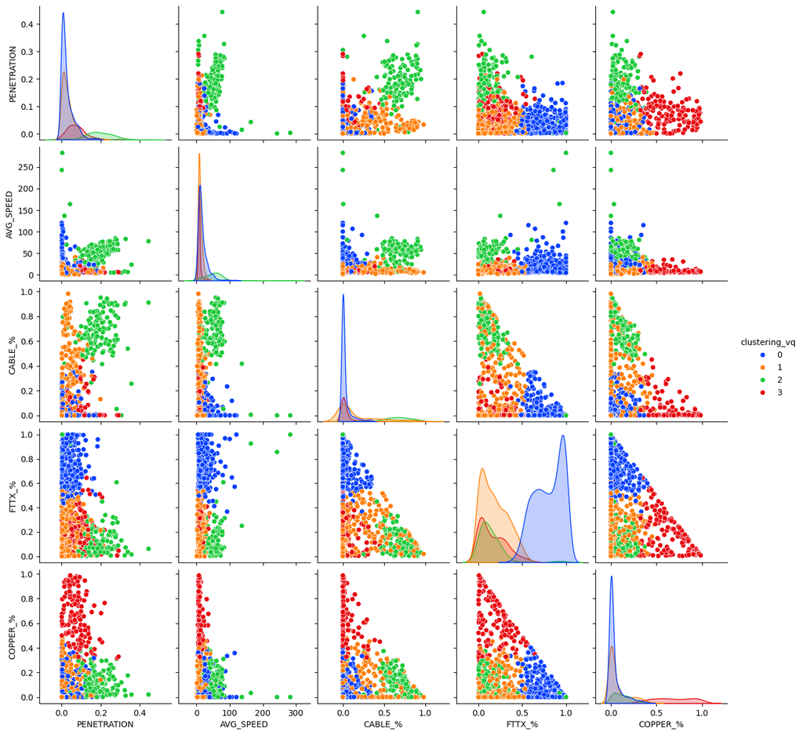

```python
features_visual=['PENETRATION','AVG_SPEED', 'CABLE_%','FTTX_%','COPPER_%','clustering_vq']
sns.pairplot(fixed_int_city_panel[features_visual], hue = 'clustering_vq', palette = 'bright')
```

### Based on the graph above please answer the question 5:

*Can cities be grouped or clustered based on other indicators in the dataset? What are the characteristics from each cluster?* **Hint: Use the characterization summary and pairplots to understand the characteristics from each cluster, sample some cities in the city panel from each cluster to understand the type of cities assigned to each cluster.**

## Please write your response here:

Por supuesto que las ciudades se pueden agrupar por clusters según sus variables a analizar.

### Based on the graph above please answer the question 6:

Liberty Latin America currently does not have a B2C (Business-to-Consumer) operation in Colombia. Based on the data provided in the case study, please provide a recommendation for the most effective entry strategy and identify specific groups of cities for its implementation.

## Please write your response here: Estrategia: Enfoque Diferenciado

Ciudades Grandes:

Objetivo: Competir con grandes jugadores (COMCEL, UNE EPM) ofreciendo internet de alta velocidad y confiabilidad con fibra óptica. Diferenciadores: Servicios premium, innovación, y sostenibilidad. Ciudades Clave: Cluster 2 (Bogotá, Medellín, Cali, Barranquilla, Bucaramanga)

Ciudades Pequeñas:

Justificación: Grandes Ciudades: Alta competencia, clientes tecnológicamente avanzados. Pequeñas Ciudades: Mercado fragmentado con oportunidades para liderazgo. Estrategia Escalonada: Control de inversión con impacto sostenido.